# Entreprise Telco :

# Analyse non supervisée

## Tandem Analysis

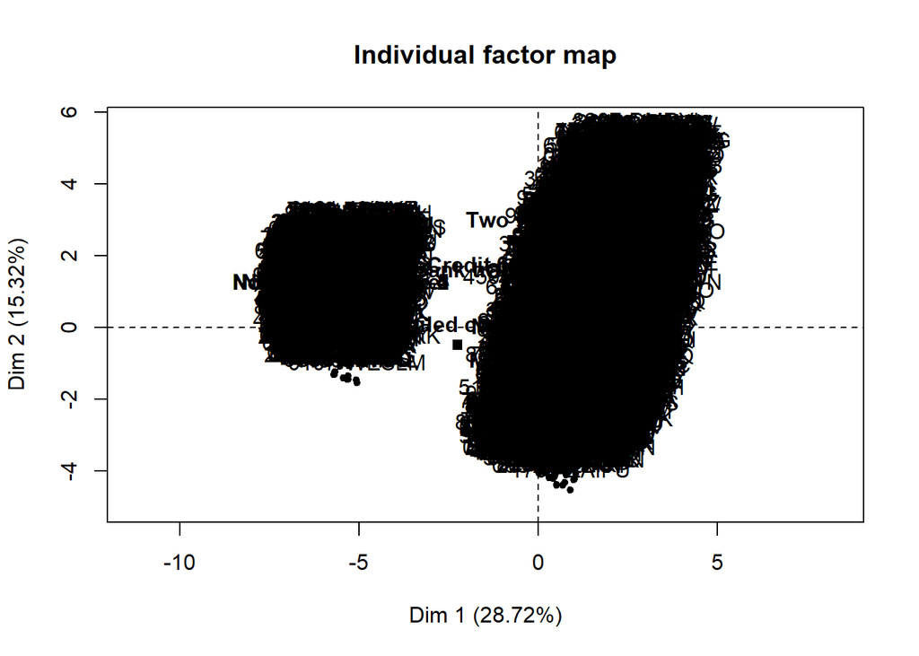

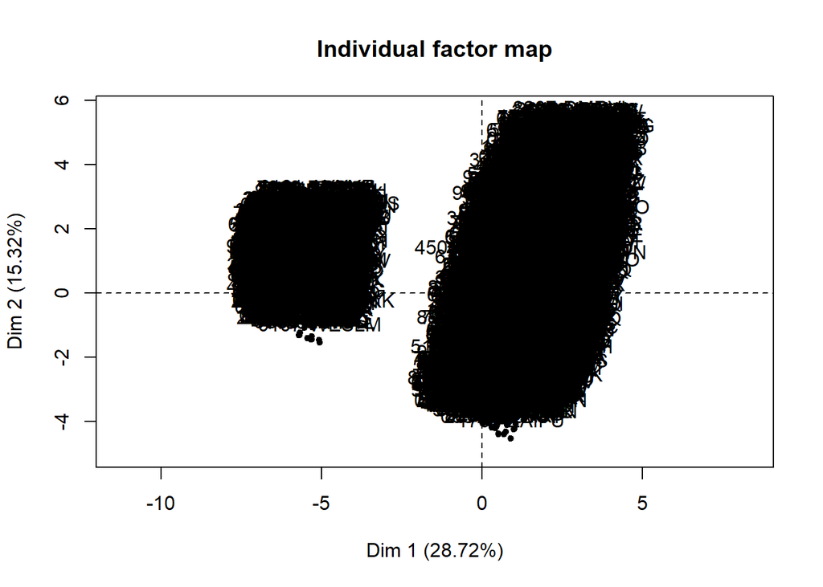

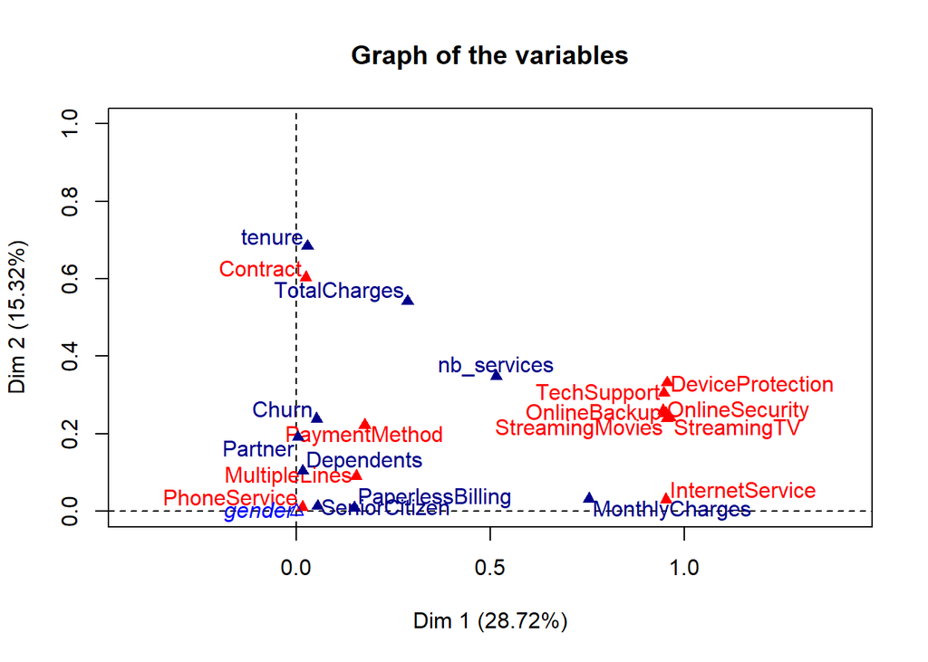

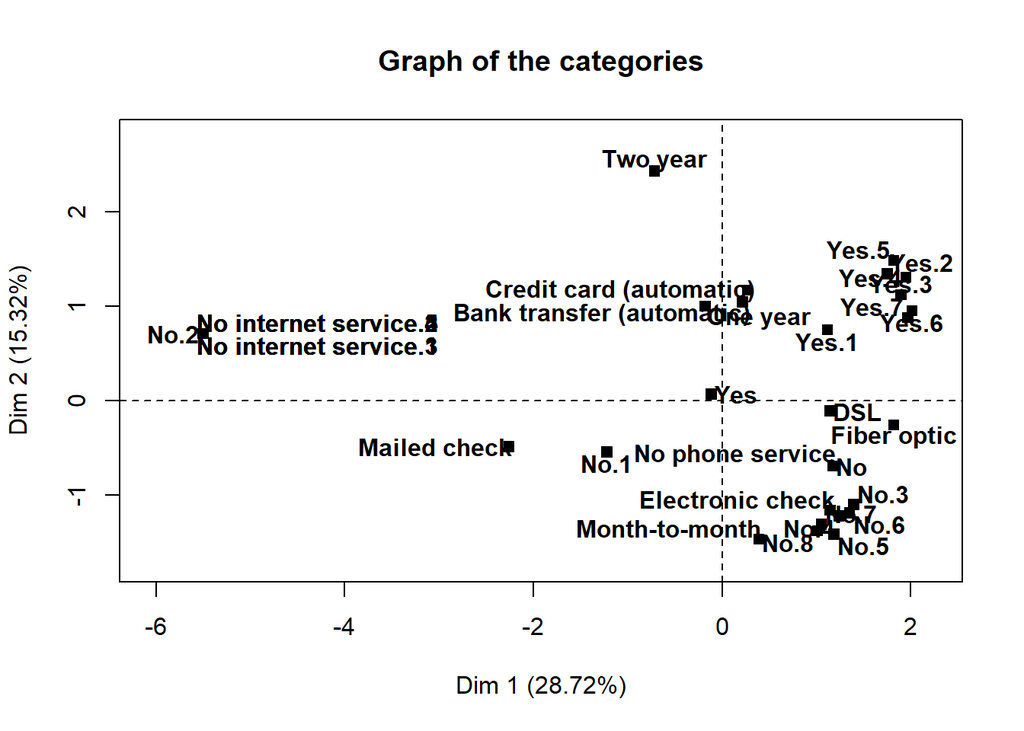

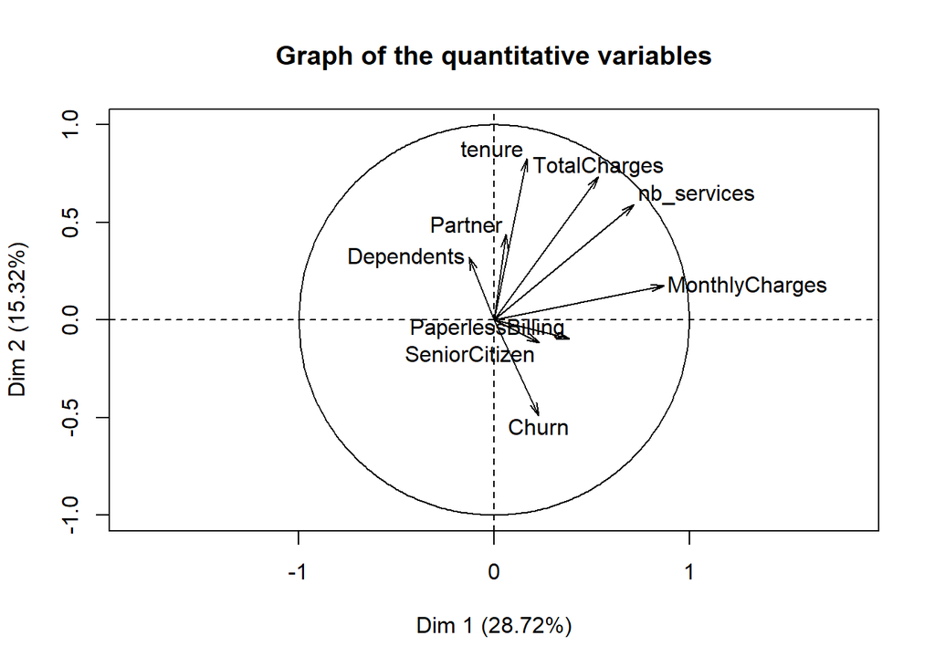

```r
set.seed(496)
rownames(tab.kNN) <- tab.kNN$customerID
tab.kNN$'customerID' =NULL
data <- tab.kNN[1:3000,]

##Réalisation de l'Analyse factorielle multi dimensionnelle
res.famd <- FAMD(data,sup.var=data$Churn , graph = T)
```

Interprétation graph variables (quanti/quali),modalités et cercle de corrélation:

Le diagnostic de ce graphique révèle que les variables de types « services » que les clients avaient souscrits semblent être les variables plus influentes au niveau de la première composante. En effet, la famille de variables « services » est en grande partie (y compris online security, streaming, device protection…) située à l’extrémité droite de l’axe 1. Par ailleurs les variables de type « démographique » à savoir partner, dependents, senior, gender ne semblent pas être déterminantes au niveau de la première composante. Autrement dit, le niveau de dispersion des individus que capte cette première dimension est en grande partie du aux variables « services ». S’agissant de la seconde composante, on peut noter que les individus se distinguent le plus par leur ancienneté (c’est-à-dire vis-à-vis de la variable tenure), leur type de contrat et également par le total des charges.

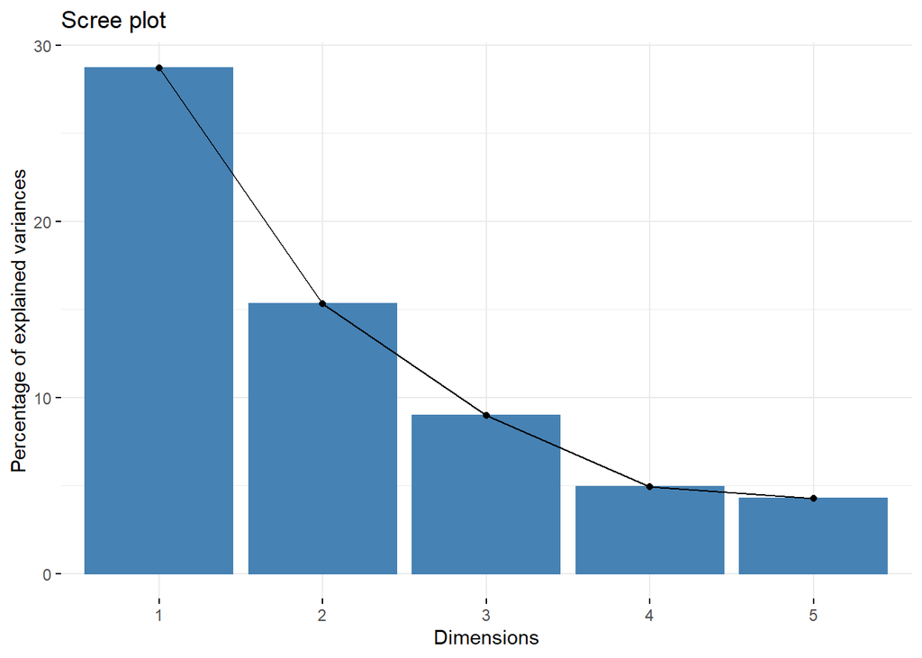

```r
eig.val <- get_eigenvalue(res.famd)
fviz_screeplot(res.famd)
```

```r
eig.val
```

```
##       eigenvalue variance.percent cumulative.variance.percent
## Dim.1   8.904598        28.724511                    28.72451
## Dim.2   4.748143        15.316590                    44.04110
## Dim.3   2.777825         8.960727                    53.00183
## Dim.4   1.532737         4.944312                    57.94614
## Dim.5   1.322238         4.265284                    62.21142
```

Interprétation Scree plot: La représentation de nuage des points-variables dans le plan factoriel permet d’avoir une idée plus claire de contributions de chaque variable dans la constitution de deux composantes principales (axe 1 et axe 2). Le premier axe capte à lui seul 28 % de l’inertie totale alors que le second retient uniquement environ 16 %. Ce premier plan factoriel retient environ 44 %.

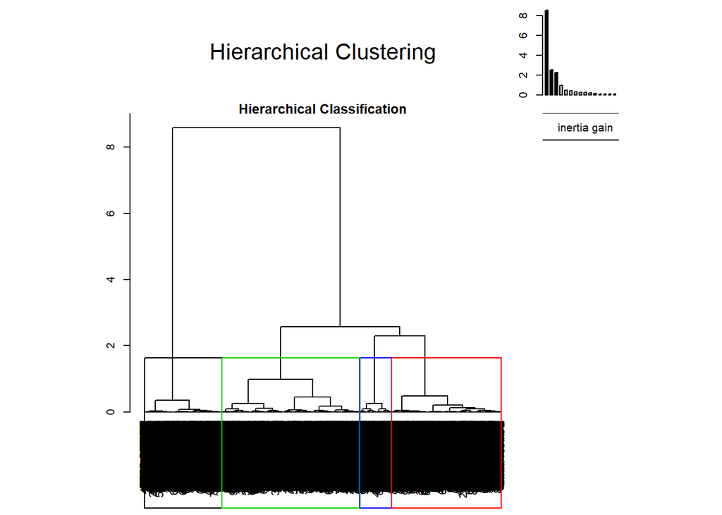

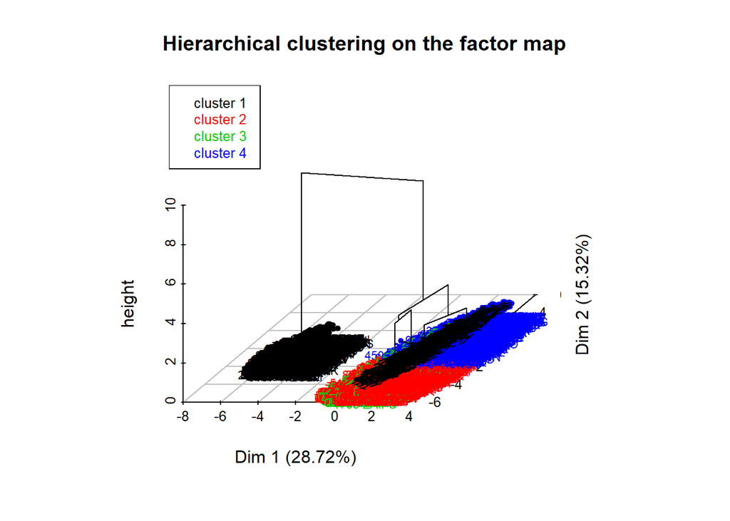

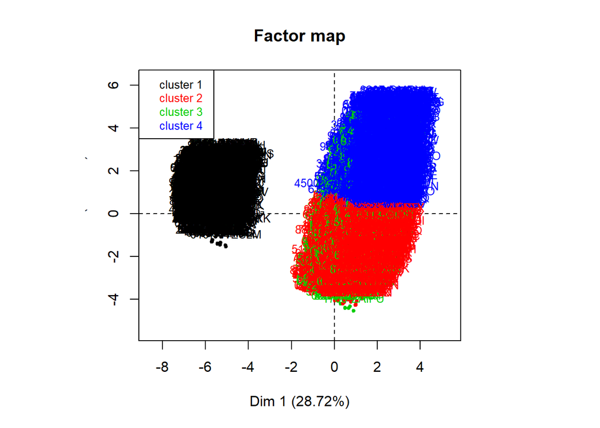

```r
## Réalisation de la CAH sur les données traitées par la FAMD
res.hcpc <- HCPC(res.famd,
                 nb.clust = -1, graph = TRUE)
```